# Public Health and Economic Impacts due to Climate Events in USA

Analysis from NOAA Storm Database

Joaquín Soliño Pérez

Feb, 5th 2021

## Synopsis

The main objecive of this document is to explain the health and economical impact due to Clima Events in USA. To do it, we'll use the [NOAA Storm Data Base](https://d396qusza40orc.cloudfront.net/repdata%2Fdata%2FStormData.csv.bz2).

Climate Events have got a very remarcable property: *a great dispersion of impact magnitudes*. This means that we usually find much events with a small or no impact impact and a small portion of total events with high and/or extremelly high impacts.

The first part of the document is dedicated to explore and prepare the data for the analysis of impacts. The second one, is dadicated to explain the results of the analysis in three dimensions:

- Total impact per Even Type
- Most harmfull and damage Event Types
- Evolution in time

for more details you can visit [NOAA / NWS Directives System] (https://www.nws.noaa.gov/directives/)

## Data Processing

This chapeter includes all the exploratory and preparation of data for the analysis.

### Load libraries

In first place, we have to load the libraries for the analysis (find a brief explanation at the side of each package:

```r
library(lubridate)      # manage dates
library(dplyr)          # for data transformation
```

```r
library(tidyr)          # for data transformation
library(stringr)        # for strings manipulation
library(ggplot2)        # for plottings
library(ggrepel)        # for plottings
library(patchwork)      # for plot layout
```

### Download data from URL

According to the project information, the data is available at [this link](https://d396qusza40orc.cloudfront.net/repdata%2Fdata%2FStormData.csv.bz2).

The steps to download the data:

1. Get the URL from the assigment, decode the URL
2. Decode the URL
3. Extract the name of the file from URL
4. Create (in not exist) the folder `data/`
5. Download (in not available) the file to the folder `data/`

Find the code bellow:

```r
# Gete de URL
my_url <- "https://d396qusza40orc.cloudfront.net/repdata%2Fdata%2FStormData.csv.bz2"
URLdecode(my_url)
```

```
## [1] "https://d396qusza40orc.cloudfront.net/repdata/data/StormData.csv.bz2"
```

```r
# The file name is the part of the URL after the last '/'.
split_URL <- strsplit(URLdecode(my_url),c("/"))       # slpit the URL string
my_file <- split_URL[[1]][length(split_URL[[1]])]     # extract the file name
my_file                                               # show file name
```

```
## [1] "StormData.csv.bz2"
```

```r
dest_file <- paste0("data/",my_file)                  # destination file (complete path)

# if 'data/' folder doesn't exist, create it
if (!dir.exists("data/")){
      dir.create("data")
      }

# if the file is not available in data/ folder, download it from URL
if(!file.exists(dest_file)){
   download.file(my_url,dest_file)
}
```

The size of the file is 46.9 MBytes, and is bz2 extension, so we must expect it has got much data.

### Read and understand the data

Next to downloaded the file, we continue reading the file data/StormData.csv.bz2 and storing it in a dataframe variable named `data`.

```r
data <- read.csv(dest_file)               # 'read.csv' can read .bz2!!
```

Now is time to explore `data`:

```r
str(data)                                 # Review the structure of data
```

```
## 'data.frame':    902297 obs. of  37 variables:
##  $ STATE__   : num  1 1 1 1 1 1 1 1 1 1 ...
##  $ BGN_DATE  : chr  "4/18/1950 0:00:00" "4/18/1950 0:00:00" "2/20/1951 0:00:00" "6/8/1951 0:00:00" ...
##  $ BGN_TIME  : chr  "0130" "0145" "1600" "0900" ...
##  $ TIME_ZONE : chr  "CST" "CST" "CST" "CST" ...
##  $ COUNTY    : num  97 3 57 89 43 77 9 123 125 57 ...
##  $ COUNTYNAME: chr  "MOBILE" "BALDWIN" "FAYETTE" "MADISON" ...
##  $ STATE     : chr  "AL" "AL" "AL" "AL" ...
##  $ EVTYPE    : chr  "TORNADO" "TORNADO" "TORNADO" "TORNADO" ...
##  $ BGN_RANGE : num  0 0 0 0 0 0 0 0 0 0 ...
##  $ BGN_AZI   : chr  "" "" "" "" ...
##  $ BGN_LOCATI: chr  "" "" "" "" ...
##  $ END_DATE  : chr  "" "" "" "" ...
##  $ END_TIME  : chr  "" "" "" "" ...
##  $ COUNTY_END: num  0 0 0 0 0 0 0 0 0 0 ...
```

[output cut: 23 more lines]

You can see there are 902297 observations and 37 variables.

The analitys is focused on harmful to population health and economic impacts, so we'll select a subset with the relevant variables for this purpose. These variables are:

- `BGN_DATE` (char): the beginning date of an event.
- `EVTYPE` (char): the event type.
- `FATALITIES` (num): the amount of fatalities due the event (# of people)
- `INJURIES` (num): the amount of injuries due the event (# of people)
- `PROPDMG` (num): the amount of property damage (without exponent) due the event
- `PROPDMGEXP` (char): character with the exponent of `PROPDMG` to obtain the property damage due the event, in USD
- `CROPDMG` (num): the amount of crops damage (without exponent) due the event, `CROPDMGEXP`) (char): character with the exponent of `CROPDMG` to obtain the crop damage due the event, in USD

```r
data <- data %>% select(
      BGN_DATE,
      EVTYPE,
      FATALITIES,
      INJURIES,
      PROPDMG,
      PROPDMGEXP,
      CROPDMG,
      CROPDMGEXP
)
```

`BGN_DATE` is a date in string format.I'll convert it to Date, using `mdy_hms` function from `lubridate` package. This variable will allow to analyze trends of health and economical impacts through the years.

```r
data$BGN_DATE <- mdy_hms(data$BGN_DATE)        # Convert BGN string to Date

data$BGN_YEAR <- year(data$BGN_DATE)

range(data$BGN_DATE)
```

```
## [1] "1950-01-03 UTC" "2011-11-30 UTC"
```

We have events registered from around 62 years.

Lets count registered data by decade:

```r
prettyNum(table((data$BGN_YEAR%/%10*10)), big.mark = ",")
```

```
##      1950      1960      1970      1980      1990      2000      2010
##  "11,191"  "25,065"  "39,110"  "75,191" "228,577" "412,828" "110,335"
```

You can see than the number of registered events have being almost doubling decade by decade (please note than 2010 decade has only data from 2 years, so we should forecast 5 times to compare with 2000-2009).

#### Health Impact

Health impact is measured in two variables: `FATALITIES` and `INJURIES`, both of them has the numer of affected people in the event.

Let see a summary of these two variables:

```r
summary(data$FATALITIES)
```

```
##     Min.  1st Qu.   Median     Mean  3rd Qu.     Max.
##   0.0000   0.0000   0.0000   0.0168   0.0000 583.0000
```

```r
summary(data$INJURIES)
```

```
##      Min.   1st Qu.    Median      Mean   3rd Qu.      Max.
##    0.0000    0.0000    0.0000    0.1557    0.0000 1700.0000
```

Please look at 1st , 2nd (Median) and 3rd quantiles; they have value 0! This is exactly what I have explaned at the beginning o this project. We are working with a very high dispersion data.

In line with the above, almost all the scales to measure nature impacts and perception magnitudes (Ritcher scale for earthquakes, Tornado force,... but also sound volume), are measured in a logaritmic scale.

In conclusion, my purpose is to measure the health impacts based in a logatimic squeme of intervals, like this:

```r
## Breaks and labels in a log-scale squeme for Health impact
health_cut_breaks <- c(0, 1, 3, 10, 30, 100, 300, 1e+3, 3e+3,1e+4,3e+4,1e+5,3e+5)
health_cut_labels <- c("[0,1)", "[1,3)", "[3,10)", "[10,30)", "[30,100)",
                       "[100,300)", "[300,1K)", "[1K,3K)","[3K,10K)","[10K,30K)",
                       "[30K,100K)","[100K,300K)")
```

Please remind that close bracket `[` means that this limit of the iterval is include, instead open bracket `(` means that this limit of the interfal is excluded. For example, `[0,1)` means that this interval has less than 1 (i.e. 0 for integer variables). `[10,30)` means that the interval considers from 10 to 29. I have used "K" to abbreviate 1000.

Let's take a look ath distribution (frequency) of events per `FATALITIES` intervals:

```r
## Conteo total de casos fatales por rangos y décadas
with(data, table(
      cut(FATALITIES, breaks = health_cut_breaks, labels = health_cut_labels,
            righ = F, ordered_result = T)
      ))
```

```
##
##       [0,1)       [1,3)      [3,10)     [10,30)    [30,100)   [100,300)
##      895323        6006         781         153          30           3
##    [300,1K)     [1K,3K)    [3K,10K)   [10K,30K)  [30K,100K) [100K,300K)
##           1           0           0           0           0           0
```

You can see the exponencial decrease pattern, with a log-scale intervals.

We do the same for `INJURIES`...

```r
## Conteo total de casos fatales por rangos y décadas
      with(data, table(
      cut(INJURIES, breaks = health_cut_breaks, labels = health_cut_labels,
            righ = F, ordered_result = T)
      ))
```

```
##
##       [0,1)       [1,3)      [3,10)     [10,30)    [30,100)   [100,300)
##      884693       10890        4442        1478         570         178
##    [300,1K)     [1K,3K)    [3K,10K)   [10K,30K)  [30K,100K) [100K,300K)
##          41           5           0           0           0           0
```

The same pattern.

I'm interested to understad the contribution of impacts per interval over the overall total impact. To do it, I'll create two new variables: `fatal_intervals` and `injur_intervals`; both are Factors to classify each event in terms of fatalities and injuries. I also create the variable `total_health` to sum fatalities and injuries of the event.

```r
data <- data %>% mutate(
      decade = factor(paste0(year(BGN_DATE) %/% 10 * 10, "s"), ordered = T),
      total_health = FATALITIES + INJURIES,        # Total health impact of the event
      fatal_intervals = cut(
            FATALITIES,
            breaks = health_cut_breaks,
            labels = health_cut_labels,
            righ = F,
            ordered_result = T
            ),
      injur_intervals = cut(
            INJURIES,
            breaks = health_cut_breaks,
            labels = health_cut_labels,
            righ = F,
            ordered_result = T
            ),
      health_intervals = cut(
            total_health,
            breaks = health_cut_breaks,
            labels = health_cut_labels,
            righ = F,
            ordered_result = T
            )
      )
```

Summarising injury impacts per interval:

```r
total_events <- length(data$BGN_DATE)
total_injur <- sum(data$INJURIES, na.rm = T)

data %>%  group_by(injur_intervals) %>%
      summarise(freq_injur = n(),
                "freq_injur(%)"= freq_injur/total_events*100,
                sum_injur = sum(INJURIES, na.rm = T),
                "sum_injur(%)" = sum_injur/total_injur*100
                )
```

```
## # A tibble: 8 x 5
##   injur_intervals freq_injur `freq_injur(%)` sum_injur `sum_injur(%)`
## * <ord>                <int>           <dbl>     <dbl>          <dbl>
## 1 [0,1)               884693       98.0              0           0
## 2 [1,3)                10890        1.21         14024           9.98
## 3 [3,10)                4442        0.492        20773          14.8
## 4 [10,30)               1478        0.164        23480          16.7
## 5 [30,100)               570        0.0632       27952          19.9
## 6 [100,300)              178        0.0197       28016          19.9
## 7 [300,1K)                41        0.00454      19487          13.9
## 8 [1K,3K)                  5        0.000554      6796           4.84
```

> You can see something very important: 98.0% of events has no impact, and 90% of impacts are concentred in 0,79% of events.

In a equivalent way, fatal impacts per interval:

```r
total_fatal <- sum(data$FATALITIES, na.rm = T)

data %>%  group_by(fatal_intervals) %>%
      summarise(freq_fatal = n(),
                "freq_fatal(%)" = freq_fatal/total_events*100,
                sum_fatal = sum(FATALITIES, na.rm = T),
                "sum_fatal(%)" = sum_fatal/total_fatal*100
                )
```

```
## # A tibble: 7 x 5
##   fatal_intervals freq_fatal `freq_fatal(%)` sum_fatal `sum_fatal(%)`
## * <ord>                <int>           <dbl>     <dbl>          <dbl>
## 1 [0,1)               895323       99.2              0           0
## 2 [1,3)                 6006        0.666         7002          46.2
## 3 [3,10)                 781        0.0866        3507          23.2
## 4 [10,30)                153        0.0170        2308          15.2
## 5 [30,100)                30        0.00332       1357           8.96
## 6 [100,300)                3        0.000332       388           2.56
## 7 [300,1K)                 1        0.000111       583           3.85
```

### Exponents for Property and Crop Damages

Exponents are used to complete the damage data. In this way, you have the variable `PROPDMG`with a number, but it has to complete with `PROPDMGEXP`. Some examples:

| PROPDMG | PROPDMGEXP | Damage |
| --- | --- | --- |
| 500 |  | 500 |
| 25 | K | 25,000 |
| 2.5 | K | 2,500 |
| 25 | 6 | 25*10<sup>6</sup> = 25,000,000 |

The values for `PROPDMGEXP` are:

```r
table(data$PROPDMGEXP)
```

```
##
##             -      ?      +      0      1      2      3      4      5      6
## 465934      1      8      5    216     25     13      4      4     28      4
##      7      8      B      h      H      K      m      M
##      5      1     40      1      6 424665      7  11330
```

For `CROPDMGEXP`:

```r
table(data$CROPDMGEXP)
```

```
##
##             ?      0      2      B      k      K      m      M
## 618413      7     19      1      9     21 281832      1   1994
```

| Exponent | Equivalence |
| --- | --- |
| '' '-' '+' '?' | 1 |
| 0 to 9 | 10<sup>x</sup> |
| h, H | 100 (10<sup>2</sup>) |
| k, K | 1,000 (10<sup>3</sup>) |
| m, M | 1,000,000 (10<sup>6</sup>) |
| b, B | 1,000,000,000 (10<sup>9</sup>) |

Next, I'll create 5 new variables:

- `prop_exp` and `crop_exp` to store the numerical equivalence of the exponent (as explained avobe).
- `property_damage` and `crop_damage` stores the damage in USD.
- `total_damage` that sums total property and crop damages in USD.

```r
data <- data %>% mutate(
            prop_exp = case_when(
                  PROPDMGEXP %in% c("H", "h") ~ 1e+2,
                  PROPDMGEXP %in% c("K", "k") ~ 1e+3,
                  PROPDMGEXP %in% c("M", "m") ~ 1e+6,
                  PROPDMGEXP %in% c("B", "b") ~ 1e+9,
                  PROPDMGEXP %in% c("", "-", "+", "?") ~ 1,
                  str_detect(PROPDMGEXP, "\\d") ~ 10 ^ as.numeric(PROPDMGEXP)
            ),
            crop_exp = case_when(
                  CROPDMGEXP %in% c("H", "h") ~ 1e+2,
                  CROPDMGEXP %in% c("K", "k") ~ 1e+3,
                  CROPDMGEXP %in% c("M", "m") ~ 1e+6,
                  CROPDMGEXP %in% c("B", "b") ~ 1e+9,
                  CROPDMGEXP %in% c("", "-", "+", "?") ~ 1,
                  str_detect(CROPDMGEXP, "\\d") ~ 10 ^ as.numeric(CROPDMGEXP)
            ),

            property_damage = PROPDMG * prop_exp,
            crop_damage = CROPDMG * crop_exp,
            total_damage = property_damage + crop_damage
)
```

Now we have calculated the damage, I'm going to explore the data. First, `property_damage`:

```r
summary(data$property_damage)
```

```
##      Min.   1st Qu.    Median      Mean   3rd Qu.      Max.
## 0.000e+00 0.000e+00 0.000e+00 4.746e+05 5.000e+02 1.150e+11
```

As I have explain previosuly, this variable has a very high dispersión. Next, we do the same with `crop_damange`

```r
summary(data$crop_damage)
```

```
##      Min.   1st Qu.    Median      Mean   3rd Qu.      Max.
## 0.000e+00 0.000e+00 0.000e+00 5.442e+04 0.000e+00 5.000e+09
```

And you can see the results are similar.

In the same way that I have made for heath, I'm going to measure the distribution and sum of the impact in base a like-logaritmic scale intervals

```r
## Breaks and labels in a log-scale squeme for Damage
damage_cut_breaks <- c(0, 1, 1e+3, 30e+3, 1e+6, 30e+6, 1e+9, 30e+9, 1e+12)
damage_cut_labels <- c("[0,1)", "[1,1K)","[1K,30K)", "[30K,1M)", "[1M,30M)",
                       "[30M,1B)","[1B,30B)", "[30B,1000B)")

data <- data %>% mutate(
      prop_dmg_intervals = cut(
            property_damage,
            breaks = damage_cut_breaks,
            labels = damage_cut_labels,
            righ = F,
            ordered_result = T
            ),
      crop_dmg_intervals = cut(
            crop_damage,
            breaks = damage_cut_breaks,
            labels = damage_cut_labels,
            righ = F,
            ordered_result = T
            ),
      total_dmg_intervals = cut(
            total_damage,
            breaks = damage_cut_breaks,
            labels = damage_cut_labels,
            righ = F,
            ordered_result = T
            )

      )
```

```r
total_events <- length(data$BGN_DATE)
total_prop_dmg <- sum(data$property_damage, na.rm = T)

data %>%  group_by(prop_dmg_intervals) %>%
      summarise(freq_prop_dmg = n(),
                "freq_prop_dmg(%)"= freq_prop_dmg/total_events*100,
                sum_prop_dmg = sum(property_damage, na.rm = T),
                "%_prop_dmg" = sum_prop_dmg/total_prop_dmg*100
                )
```

```
## # A tibble: 8 x 5
##   prop_dmg_intervals freq_prop_dmg `freq_prop_dmg(%)` sum_prop_dmg `%_prop_dmg`
## * <ord>                      <int>              <dbl>        <dbl>        <dbl>
## 1 [0,1)                     663128          73.5           2.21e 0     5.16e-10
## 2 [1,1K)                     15641           1.73          5.26e 6     1.23e- 3
## 3 [1K,30K)                  154501          17.1           1.33e 9     3.11e- 1
## 4 [30K,1M)                   58088           6.44          9.45e 9     2.21e+ 0
## 5 [1M,30M)                   10140           1.12          5.30e10     1.24e+ 1
## 6 [30M,1B)                     760           0.0842        8.87e10     2.07e+ 1
## 7 [1B,30B)                      37           0.00410       1.29e11     3.02e+ 1
## 8 [30B,1000B)                    2           0.000222      1.46e11     3.42e+ 1
```

> You can see that 64% of total property damage is concentrated in 39 events, which represents the 0,0043% of all the events

```r
total_crop_dmg <- sum(data$crop_damage, na.rm = T)

data %>%  group_by(crop_dmg_intervals) %>%
      summarise(freq_crop_dmg = n(),
                "freq_crop_dmg(%)"= freq_crop_dmg/total_events*100,
                sum_crop_dmg = sum(crop_damage, na.rm = T),
                "%_crop_dmg" = sum_crop_dmg/total_crop_dmg*100
                )
```

```
## # A tibble: 7 x 5
##   crop_dmg_intervals freq_crop_dmg `freq_crop_dmg(%)` sum_crop_dmg `%_crop_dmg`
## * <ord>                      <int>              <dbl>        <dbl>        <dbl>
## 1 [0,1)                     880198          97.6                 0     0
## 2 [1,1K)                       830           0.0920         329701     0.000671
## 3 [1K,30K)                   12248           1.36        103700580     0.211
## 4 [30K,1M)                    7143           0.792      1250811900     2.55
## 5 [1M,30M)                    1652           0.183      8442160000    17.2
## 6 [30M,1B)                     222           0.0246    26797190000    54.6
## 7 [1B,30B)                       4           0.000443  12510000000    25.5
```

#### Event Types

In the Service Instruction 10-1605 (august 17, 2007) related to STORM DATA PREPARATION, the NWS establishes the Permitted Storm Data Events (section 2.1).

You can find this document at the NOAA Webpage in [this link](https://www.nws.noaa.gov/directives/sym/pd01016005curr.pdf):

According to this directive, there are 48 Types of Events. I have copied them in a comma separated values file, to test the number of matchs and to solve errors.

```r
event_type_table <- read.csv("data/EventTable.scv")
event_type_table$Event.Name
```

```
##  [1] "Astronomical Low Tide"    "Avalanche"
##  [3] "Blizzard"                 "Coastal Flood"
##  [5] "Cold/Wind Chill"          "Debris Flow"
##  [7] "Dense Fog"                "Dense Smoke"
##  [9] "Drought"                  "Dust Devil"
## [11] "Dust Storm"               "Excessive Heat"
## [13] "Extreme Cold/Wind Chill"  "Flash Flood"
## [15] "Flood"                    "Frost/Freeze"
## [17] "Funnel Cloud"             "Freezing Fog"
## [19] "Hail"                     "Heat"
## [21] "Heavy Rain"               "Heavy Snow"
## [23] "High Surf"                "High Wind"
## [25] "Hurricane (Typhoon)"      "Ice Storm"
## [27] "Lake-Effect Snow"         "Lakeshore Flood"
## [29] "Lightning"                "Marine Hail"
## [31] "Marine High Wind"         "Marine Strong Wind"
## [33] "Marine Thunderstorm Wind" "Rip Current"
## [35] "Seiche"                   "Sleet"
## [37] "Storm Surge/Tide"         "Strong Wind"
## [39] "Thunderstorm Wind"        "Tornado"
## [41] "Tropical Depression"      "Tropical Storm"
## [43] "Tsunami"                  "Volcanic Ash"
## [45] "Waterspout"               "Wildfire"
## [47] "Winter Storm"             "Winter Weather"
```

If we count the unique Event Types from the data:

```r
length(unique(data$EVTYPE))
```

```
## [1] 985
```

We are going to review the number of events than don't match the NWS Event Type table

```r
no_match <- data$EVTYPE[!(data$EVTYPE %in% toupper(event_type_table$Event.Name))]
length(no_match)
```

```
## [1] 267022
```

> 267,022 events dont match the NWS Event Type Table. This represents 29.5936% of total observations.

To fix this, we start with the TOP 40 (discrecional) Event Types, and check de root cause of the missmatch:

```r
sorted_events <- sort(table(data$EVTYPE),decreasing = T)
head(sorted_events,40)        # List TOP 40 Event Types
```

```
##
##                     HAIL                TSTM WIND        THUNDERSTORM WIND
##                   288661                   219940                    82563
##                  TORNADO              FLASH FLOOD                    FLOOD
##                    60652                    54277                    25326
##       THUNDERSTORM WINDS                HIGH WIND                LIGHTNING
##                    20843                    20212                    15754
##               HEAVY SNOW               HEAVY RAIN             WINTER STORM
##                    15708                    11723                    11433
##           WINTER WEATHER             FUNNEL CLOUD         MARINE TSTM WIND
##                     7026                     6839                     6175
## MARINE THUNDERSTORM WIND               WATERSPOUT              STRONG WIND
##                     5812                     3796                     3566
##     URBAN/SML STREAM FLD                 WILDFIRE                 BLIZZARD
##                     3392                     2761                     2719
##                  DROUGHT                ICE STORM           EXCESSIVE HEAT
##                     2488                     2006                     1678
##               HIGH WINDS         WILD/FOREST FIRE             FROST/FREEZE
##                     1533                     1457                     1342
##                DENSE FOG       WINTER WEATHER/MIX           TSTM WIND/HAIL
##                     1293                     1104                     1028
##  EXTREME COLD/WIND CHILL                     HEAT                HIGH SURF
##                     1002                      767                      725
##           TROPICAL STORM           FLASH FLOODING             EXTREME COLD
##                      690                      682                      655
##            COASTAL FLOOD         LAKE-EFFECT SNOW        FLOOD/FLASH FLOOD
##                      650                      636                      624
##                LANDSLIDE
##                      600
```

```r
top_freq_event <- names(head(sorted_events,40)) # Store the Names
# The name of the Events that missmatch Table and belong to TOP 25 Events occur
top_freq_event[!(top_freq_event %in% toupper(event_type_table$Event.Name))]
```

```
##  [1] "TSTM WIND"            "THUNDERSTORM WINDS"   "MARINE TSTM WIND"
##  [4] "URBAN/SML STREAM FLD" "HIGH WINDS"           "WILD/FOREST FIRE"
##  [7] "WINTER WEATHER/MIX"   "TSTM WIND/HAIL"       "FLASH FLOODING"
## [10] "EXTREME COLD"         "FLOOD/FLASH FLOOD"    "LANDSLIDE"
```

We can see that missmatches have different causes: use of abbreviations (`{TSTM}` *vs* `{THUNDERSTORM}`, `FLD` *vs* `FLOOD`), plural forms (`WINDS` *vs* `WIND`), mix 2 types (`TSTM WIND/HAIL`, FLOOD/FLASH FLOOD) and other that not correspond to a valid Event Type and must be fixed:

- URBAN/SML STREAM FLD will be assigned to FLOOD. Please check [Glosary - NOAA](https://w1.weather.gov/glossary/index.php?word=Urban+and+Small+Stream+Flood+Advisory)) for more information about this event.
- WILD/FOREST FIRE must be assigned to WILDFIRE. No other option is available for FIRE.
- WINTER WEATHER/MIX will be assigned to WINTER WEATHER. MIX doesn't exist.
- Other mixed valid options, like TSTM WIND/HAIL or FLOOD/FLASH FLOOD will keep as their are, because we don't have criteria to select wich type predominates over the other one.

Next, you'll find the corrections made over a new variable `EVTYPE2` (for non-destructive comparisson):

```r
data$EVTYPE2 <- data$EVTYPE         # copy EVTYPE to EVTYPE2

# Fix Typing errors
data$EVTYPE2 <- str_replace(data$EVTYPE2,"AVALANCE","AVALANCHE")  # typing error
# Fix Plural
data$EVTYPE2 <- str_replace(data$EVTYPE2,"WINDS","WIND")
data$EVTYPE2 <- str_replace(data$EVTYPE2,"CURRENTS","CURRENT")
# Replace Abbreviations
data$EVTYPE2 <- str_replace(data$EVTYPE2,"FLD","FLOOD")
data$EVTYPE2 <- str_replace(data$EVTYPE2,"TSTM","THUNDERSTORM")
# Fix Gerund instead noun
data$EVTYPE2 <- str_replace(data$EVTYPE2,"FLOODING","FLOOD")
# Fix some events - no other valid choice
data$EVTYPE2 <- str_replace(data$EVTYPE2,"URBAN/SML STREAM FLOOD","FLOOD")
data$EVTYPE2 <- str_replace(data$EVTYPE2,"WILD/FOREST FIRE","WILDFIRE")
data$EVTYPE2 <- str_replace(data$EVTYPE2,"WINTER WEATHER/MIX","WINTER WEATHER")
data$EVTYPE2 <- str_replace(data$EVTYPE2,"EXTREME COLD","EXTREME COLD/WIND CHILL")
data$EVTYPE2 <- str_replace(data$EVTYPE2,"EXTREME WINDCHILL","EXTREME COLD/WIND CHILL")

# Fix some event related to high health and/or economic impact
data$EVTYPE2[str_detect(data$EVTYPE2,"BLIZZARD")] <- "BLIZZARD"
data$EVTYPE2[str_detect(data$EVTYPE2,"HURRICANE")] <- "HURRICANE (TYPHOON)"
data$EVTYPE2[str_detect(data$EVTYPE2,"TYPHOON")] <- "HURRICANE (TYPHOON)"
data$EVTYPE2[str_detect(data$EVTYPE2,"FLASH FLOOD")] <- "FLASH FLOOD"
data$EVTYPE2 <- str_replace(toupper(data$EVTYPE2),"CSTL","COASTAL")
data$EVTYPE2[str_detect(toupper(data$EVTYPE2),"COASTAL FLOOD")] <- "COASTAL FLOOD"
data$EVTYPE2[str_detect(toupper(data$EVTYPE2),"MAJOR FLOOD")] <- "FLOOD"
data$EVTYPE2[str_detect(toupper(data$EVTYPE2),"RIVER F")] <- "FLOOD"
data$EVTYPE2[str_detect(toupper(data$EVTYPE2),"STORM SURGE")] <- "STORM SURGE/TIDE"
data$EVTYPE2[str_detect(toupper(data$EVTYPE2),"^FOG$")] <- "DENSE FOG"
data$EVTYPE2[str_detect(toupper(data$EVTYPE2),"HEAVY SURF")] <- "HIGH SURF"
data$EVTYPE2[str_detect(toupper(data$EVTYPE2),"HEAT WAVE")] <- "EXCESSIVE HEAT"
data$EVTYPE2[str_detect(toupper(data$EVTYPE2),"HIGH WIND/COLD")] <- "COLD/WIND CHILL"
data$EVTYPE2[str_detect(toupper(data$EVTYPE2),"RECORD COLD")] <- "EXTREME COLD/WIND CHILL"
data$EVTYPE2[str_detect(toupper(data$EVTYPE2),"EXTREME COLD/WIND")] <- "EXTREME COLD/WIND CHILL"
```

After these changes, we repeat the check for missmatch. First, in number of events:

```r
length(unique(data$EVTYPE2))
```

```
## [1] 791
```

```r
no_match2 <- data$EVTYPE2[!(data$EVTYPE2 %in% toupper(event_type_table$Event.Name))]
length(no_match2)
```

```
## [1] 7608
```

> We have reduced the number of missmatch events from 267,022 to 7608. That means 0.8432%, which is more reasonable value than previous one.

Now, I test the coverage of Event Types related to health impact:

```r
sum(data$total_health[data$EVTYPE2 %in% toupper(event_type_table$Event.Name)], na.rm = T)/sum(data$total_health, na.rm = T)
```

```
## [1] 0.9853539
```

> Over 98,5% doing match with valid Type Event is very reasonable data coverage of healt impact for the analysis.

Finally, I test the coverage of Event Types related to damage:

```r
sum(data$total_damage[data$EVTYPE2 %in% toupper(event_type_table$Event.Name)], na.rm = T)/sum(data$total_damage, na.rm = T)
```

```
## [1] 0.9820172
```

> Over 98% doing match with valid Type Event is a very reasonable data coverage of damages impact for the analysis.

## Results and Analysis

Results are explained in two separate sections: health impact and economical impact.

### Most harmful events to population health

To present the results, I have made some plots to show:

- Total amount of impacts
- Zoom in most harmfull events: types and evolution in time
- Relation betwen fatalities and injuries (most harmfull events)

I'll use som plot to support my conclusions.

*Note: that the number of injuries and fatalities are shown in logaritmic scale.*

First, the show the total summary of impact per event type, broken down by fatalities and inuries.

```r
# TOP 10 event types with FATALITIEs impact
top_sum_event_fatal <- data %>% group_by(EVTYPE2) %>%
      summarise(sum = sum(FATALITIES, na.rm = T)) %>%
      arrange(desc(sum)) %>% slice_head(n=10)

# TOP 10 event types with INJURIES impact
top_sum_event_injur <- data %>% group_by(EVTYPE2) %>%
      summarise(sum = sum(INJURIES, na.rm = T)) %>% arrange(desc(sum)) %>%
      slice_head(n=10)

# Make de union of TOP fatalities and TOP injuries
top_sum_event_health <- unique(c(top_sum_event_fatal$EVTYPE2,
                                 top_sum_event_injur$EVTYPE2))

# Summary of impacts by type of health_impact
top_health <- data %>% ungroup() %>%
      filter(EVTYPE2 %in% top_sum_event_health) %>%
      select(EVTYPE2, FATALITIES, INJURIES) %>%
      pivot_longer(
             cols = c("FATALITIES", "INJURIES"),
             names_to = "health_impact",
             values_to = "impact") %>%
      group_by(EVTYPE2, health_impact) %>%
      summarise(sum = sum(impact, na.rm = T)) %>%
      ungroup() %>%
      arrange(health_impact,sum) %>% filter(sum>0) %>%
      mutate(order = row_number())
```

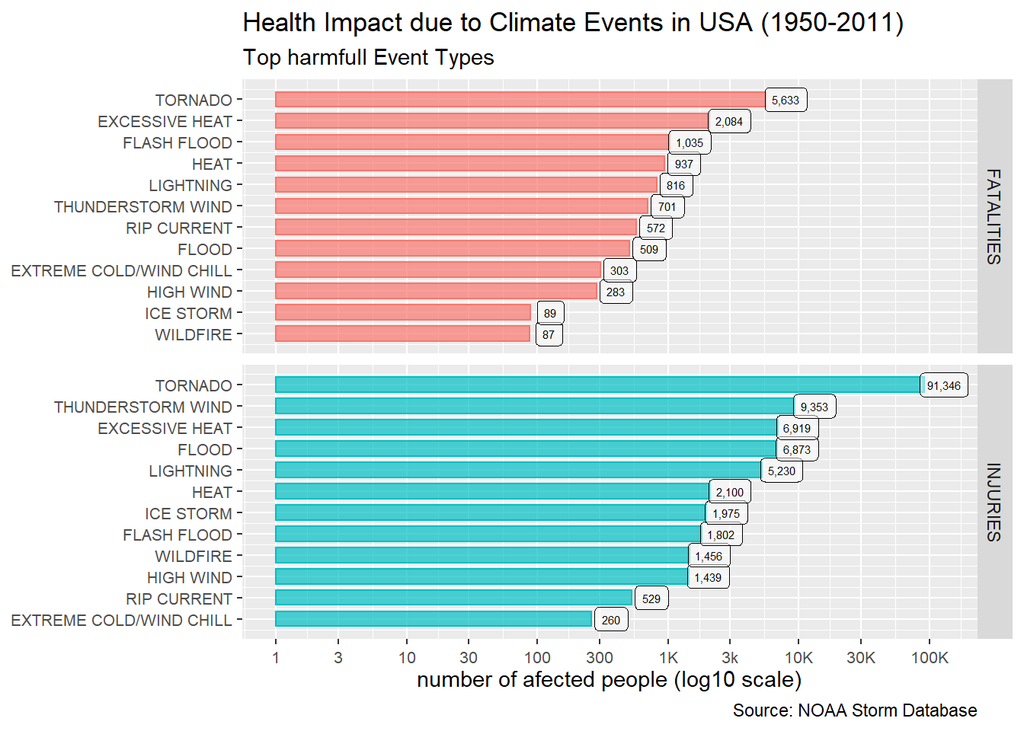

```r
# Plot Total Impact (Fatalities and Injuries)
plot_top_health <- top_health %>% ggplot() +
      geom_col(aes(x = order, y = sum, color = health_impact,
                   fill = health_impact), alpha = 0.7, width = 0.7) +
      geom_label(data= top_health,
                aes(order, y= sum, label = formatC(round(sum,0), format = "f", big.mark = ",", digits = 0)),
                nudge_y = +0.15, size = 2, label.size = 0.1, alpha = 0.5) +
      facet_grid(health_impact~.,scales = "free") +
      # Labels for thitle, axes and caption
      labs( x = NULL,
            y = "number of afected people (log10 scale)",
            title = "Health Impact due to Climate Events in USA (1950-2011)",
            subtitle = "Top harmfull Event Types",
            caption = "Source: NOAA Storm Database"
            ) +
      # Customize scales, an theme
      scale_x_continuous(
            breaks = top_health$order,
            labels = top_health$EVTYPE2) +
      scale_y_log10(breaks = health_cut_breaks[-1],
                    labels = c("1","3","10","30","100","300","1K","3k","10K",
                               "30K","100K","300K")) +
      coord_flip() +
      theme(title = element_text(size = 11),
            legend.title = element_blank(),
            axis.text.x = element_text(angle = 0,vjust = .5,size = 8),
            axis.text.y = element_text(size = 8),
            legend.position = "none")
plot_top_health
```

You can see that TORNADO is the most harmfull event in terms of total fatalities and injuries, over all the period with data stored.

Next, we make a zoom in the most harmfull events in time. Considering the analysis impact done in the previous point I have chosen the next criteria:

```r
# table(data$fatal_intervals>="[30,100)")
health_xtreme <- data %>%
      filter(fatal_intervals >= "[30,100)" |
                   data$injur_intervals >= "[300,1K)") %>%
      select(BGN_DATE, EVTYPE2, FATALITIES, INJURIES) %>%
      pivot_longer(cols = c("FATALITIES", "INJURIES"),
             names_to = "health_type", values_to = "impact") %>%
      filter(impact > 0)      # delete registers with 0 value, due to log-scale

plot_xtreme <- health_xtreme %>% ggplot() +
      geom_point(aes(x = as.Date(BGN_DATE), y = impact,
                color = EVTYPE2, fill = EVTYPE2), alpha = 0.8,size = 3) +
      geom_text_repel(data = health_xtreme %>% arrange(desc(impact)) %>% slice_head(n=20),
                aes(as.Date(BGN_DATE), impact, label = EVTYPE2),
                size=2, max.overlaps = 15)+
      facet_grid(. ~ health_type) +
      scale_y_log10(breaks = c(1,3,10,30,100,300,1e+3,3e+3, 1e+4,3e+4,1e+5,3e+5),
                    labels = c("1","3","10","30","100","300","1K","3k","10K",
                               "30K","100K","300K")) +
      scale_x_date(date_breaks = "5 years") +
      labs(x= "Year",
           y= "Impact (number of people - log10 scale)",
           title = "Extremelly harmfull Climate Events per year",
           subtitle = "High imact (over 30 fatalies or over 300 injuries)",
            caption = "Source: NOAA Storm Database") +
      theme(title = element_text(size = 12),
            axis.text.x = element_text(angle = 90,vjust = .5,size = 8),
            axis.text.y = element_text(size = 8),
            legend.title = element_blank(),
            legend.text = element_text(size = 6),
            legend.position = "bottom")
```

Finally, I prepared a scatter plot looking for relation between fatalities and injuries.

```r
# table(data$fatal_intervals>="[30,100)")
fatal_vs_injur <- data %>%
      filter(fatal_intervals >= "[30,100)" |
                   data$injur_intervals >= "[300,1K)") %>%
      select(BGN_DATE, EVTYPE2, FATALITIES, INJURIES, fatal_intervals, injur_intervals)

plot_fatal_vs_injur <- fatal_vs_injur %>% ggplot() +
      geom_point(aes(x = FATALITIES, y = INJURIES, color = EVTYPE2,
                fill = EVTYPE2), alpha = 0.8,size = 3) +
      facet_grid(injur_intervals ~ fatal_intervals, scales = "free") +
      scale_y_continuous(breaks = health_cut_breaks[-1],
                         labels = c("1","3","10","30","100","300","1K","3k",
                                    "10K", "30K","100K","300K")) +
      scale_x_continuous(breaks = health_cut_breaks[-1],
                         labels = c("1","3","10","30","100","300","1K","3k",
                                    "10K", "30K","100K","300K")) +
      labs(x= "Number of fatalities (log10 scale)",
           y= "Number o injuries (log10 scale)",
           title = "Extremelly harmfull Climate Events",
           subtitle = "Dispersion Fatalities vs Infuries (more than 30 fatal or 300 injuries",
           caption = "Source: NOAA Storm Database") +
      theme(title = element_text(size = 12),
            axis.text.x = element_text(angle = 90,vjust = .5,size = 7),
            axis.text.y = element_text(size = 7),
            legend.title = element_blank(),
            legend.text = element_text(size = 6),
            legend.position = "bottom")
```

Next, we define the layout for the multiple plotting. You'll find the figure with 2 plots:

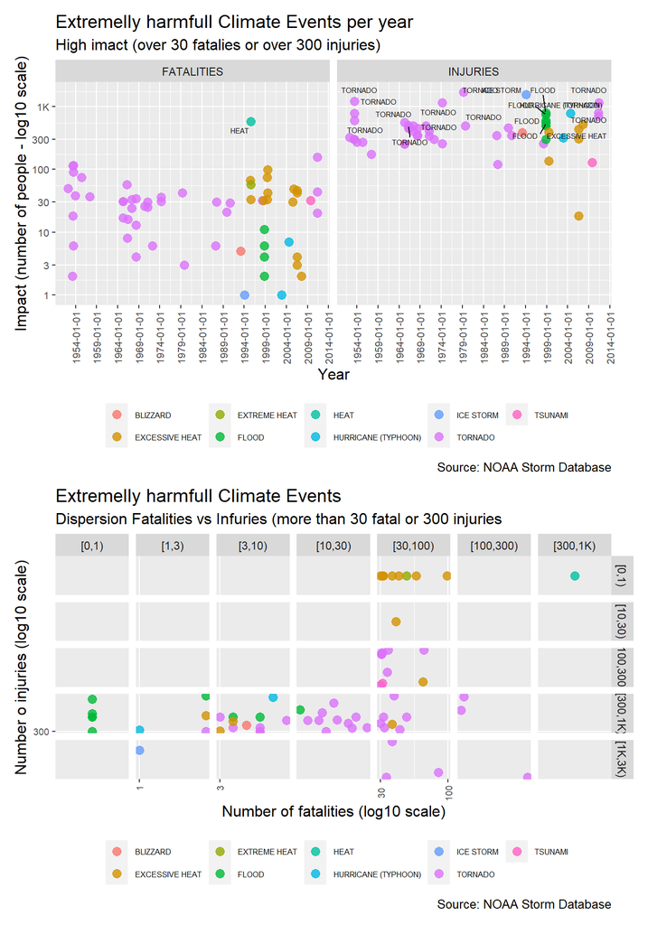

```r
# Prepare Layout for the multiple plot
layout <- "
A
A
B
B
"

plot_xtreme + plot_fatal_vs_injur + plot_layout(design = layout)
```

Our conclusion looking at the previous grahp is:

Looking for the scatterplot between fatalities and injuries, we can conclude:

1. Events with very high impact in injuries but low in fatalities: FLOOD, ICE STORM, HURRICANE
2. Events with very high impact in fatalities but low in injuries: HEAT
3. Events with both very hihg impact in fatalities and injuries: TORNADO

So, in my opinnion, TORNADOs and HEAT (including some heat variants) are, by far, the most harmfull events for population health.

### Events with greatest economic consequences

The conclusions for the economic impacts will be presented in a similar way than health impacts.

```r
# TOP 10 event types with Property damage
top_sum_event_prop <- data %>% group_by(EVTYPE2) %>%
      summarise(sum = sum(property_damage, na.rm = T)) %>%
      arrange(desc(sum)) %>% slice_head(n=10)

# TOP 10 event types with crop damage
top_sum_event_crop <- data %>% group_by(EVTYPE2) %>%
      summarise(sum = sum(crop_damage, na.rm = T)) %>% arrange(desc(sum)) %>%
      slice_head(n=10)

# Make de union of TOP fatalities and TOP injuries
top_sum_event_damage <- unique(c(top_sum_event_prop$EVTYPE2,
                                 top_sum_event_crop$EVTYPE2))

# Summary of property and crop damages (in USD)
top_damage <- data %>% ungroup() %>%
      select(EVTYPE2, property_damage, crop_damage) %>%
      filter(EVTYPE2 %in% top_sum_event_health) %>%
      group_by(EVTYPE2) %>%
      summarise("PROPERTY" = sum(property_damage, na.rm = T),
                "CROP" = sum(crop_damage, na.rm = T)) %>%
      ungroup() %>%
      pivot_longer(
             cols = c("PROPERTY", "CROP"),
             names_to = "damage_type",
             values_to = "amount") %>%
      arrange(damage_type,amount) %>%
      mutate(order = row_number()) %>%
      filter(amount>0)


# Plot Total Impact (Fatalities and Injuries)
plot_top_damage <- top_damage %>% ggplot() +
      geom_col(aes(x = order, y = amount, color = damage_type,
                   fill = damage_type), alpha = 0.5, width = 0.7) +
      geom_label(data= top_damage,
                aes(order, y= amount,
                    label = paste("USD",round(amount/1e+9,2),"B")),
                nudge_y = 0.1, size = 2, label.size = 0.1, alpha = 0.5) +
      facet_grid(damage_type ~., scales = "free", space = "free") +
      # Titles for plot, axiss and caption
      labs( x = "Event Type",
            y = "Damage - USD - (log10 scale)",
            title = "Economical Impact due to Climate Events in USA (1950-2011)",
            subtitle = "Top impact Event Types",
            caption = "Source: NOAA Storm Database"
            ) +
      # Some customization for scales and theme
      scale_x_continuous(
            breaks = top_damage$order,
            labels = top_damage$EVTYPE2) +
      scale_y_log10(breaks = c(0, 1, 1e+3, 30e+3, 1e+6, 30e+6, 1e+9, 30e+9, 1e+12),
                    labels = c("1","3","1K","30K","1M","30M","1B","30B","1000B")) +
      coord_flip() +
      theme(title = element_text(size = 11),
            legend.title = element_blank(),
            axis.text.x = element_text(angle = 0,vjust = .5,size = 8),
            axis.text.y = element_text(size = 8),
            legend.position = "none")
```

Second, que prepare a scatter plot with the TOP 50 Events by economical impact.

```r
# remind defined above:
# damage_cut_breaks <- c(0, 1, 1e+3, 30e+3, 1e+6, 30e+6, 1e+9, 30e+9, 1e+12)
# damage_cut_labels <- c("[0,1)", "[1,1K)","[1K,30K)", "[30K,1M)", "[1M,30M)",
#                        "[30M,1B)","[1B,30B)", "[30B,1000B)")

# table(data$fatal_intervals>="[1B,30B)")
xtreme_damage <- data %>%
      filter(prop_dmg_intervals >= "[30M,1B)" |
                   crop_dmg_intervals >= "[30M,1B)") %>%
      select(BGN_DATE, EVTYPE2, property_damage,crop_damage) %>%
      pivot_longer(cols = c("property_damage", "crop_damage"),
             names_to = "damage_type", values_to = "amount") %>%
      arrange(desc(amount)) %>% slice_head(n=50) %>%
      filter(amount > 0)      # delete registers with 0 value, due to log-scale

# Scatter plot of date vs eonomical impact, faceted by type of impact
plot_xtreme_damage <- xtreme_damage %>% ggplot() +
      geom_point(
            aes(x = as.Date(BGN_DATE), y = amount,
                color = EVTYPE2, fill = EVTYPE2), alpha = 0.8,size = 3) +
      geom_text_repel(data = xtreme_damage %>% arrange(desc(amount)) %>%
                            slice_head(n=20),
                aes(as.Date(BGN_DATE), amount, label = EVTYPE2),
                size=2, max.overlaps = 15)+
      facet_wrap(. ~ damage_type,
                 labeller = labeller(damage_type = c(property_damage =
                                     "PROPERTY",crop_damage = "CROP"))) +
      # Tittle for graph, axis and caption
      labs(x= "Date",
           y= "Damage - USD (log10 scale)",
           title = "Extremelly economical damage climate events per year",
           subtitle = "Top 50 economical damage",
            caption = "Source: NOAA Storm Database") +
      # Some customization for axiss an themes
      scale_y_log10(breaks = damage_cut_breaks) +
      scale_x_date(date_breaks = "2 years") +
            theme(title = element_text(size = 12),
            axis.text.x = element_text(angle = 90,vjust = .5,size = 8,
                                       face = "bold"),
            axis.text.y = element_text(face = "bold"),
            legend.title = element_blank(),
            legend.text = element_text(size = 6),
            legend.position = "bottom")
```

Finally here is the results for the analysis. Please note that I'm using logaritmic scale for best detail in low figures and high figures.

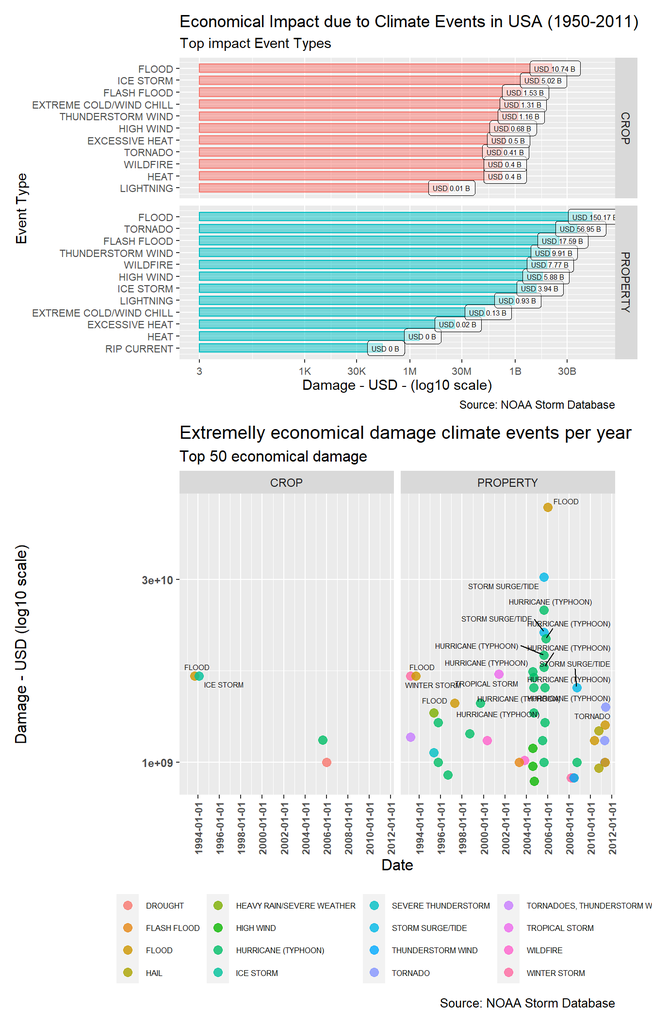

Ranking of Top Economical Damage Events and Scatter plot of TOP Extreme Damage Events

```r
plot_top_damage / plot_xtreme_damage
```

In the upper side of the plot, you can see:

In the lower part of the figure you can see the scatter plot of top 50 most extremely economical impact event. You can see:

- Crop damage: 4 events in the TOP 50
- Property damage: : 46 events in the TOP 50

You can conclude clearly in the plot that the TOP destructive events have much relevance in property damage vs crop damages.

Finally, I consider remarkable than the period for this TOP 50 goes from 1993 to 2011. I really don't have and answer to the reason of why there are not any of this TOP events between 1950 and 1993. I suppose this is very much complex analysis to understand climate trends related to Climate Change and Global Warming.